# estadistica-inferencial

Andrés Aldana

10/25/2021

# Muestreo

## Muestreo aleatorio simple (con reposición) o m.a.s.

```r
(x = sample(1:100, 15, replace=TRUE))
```

```
##  [1]  7 38 46 58 12 70 64 38 69 23 76 51 60 18 60
##
```

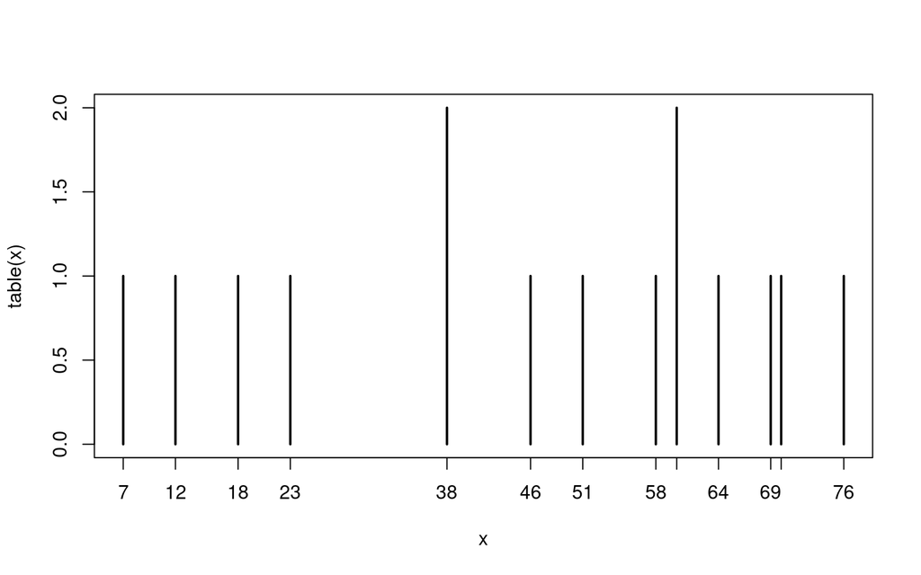

```r
plot(table(x))
```

obtener una muestra de tamaño 10 del dataset `iris` con reposición

```r
flores.elegidas.10.con = sample(1:150, 10, TRUE)
(muestra.iris.10.con = iris[flores.elegidas.10.con,])
```

```
##     Sepal.Length Sepal.Width Petal.Length Petal.Width    Species
## 125          6.7         3.3          5.7         2.1  virginica
## 131          7.4         2.8          6.1         1.9  virginica
## 46           4.8         3.0          1.4         0.3     setosa
## 104          6.3         2.9          5.6         1.8  virginica
## 26           5.0         3.0          1.6         0.2     setosa
## 101          6.3         3.3          6.0         2.5  virginica
## 86           6.0         3.4          4.5         1.6 versicolor
## 98           6.2         2.9          4.3         1.3 versicolor
## 147          6.3         2.5          5.0         1.9  virginica
## 68           5.8         2.7          4.1         1.0 versicolor
```

## Muestreo aleatorio sin reposición

```r
(x = sample(1:100, 15, replace=FALSE))
```

```
##  [1]  86   5  73  63  38  18  43  59  70 100  92  97  79  34  22
```

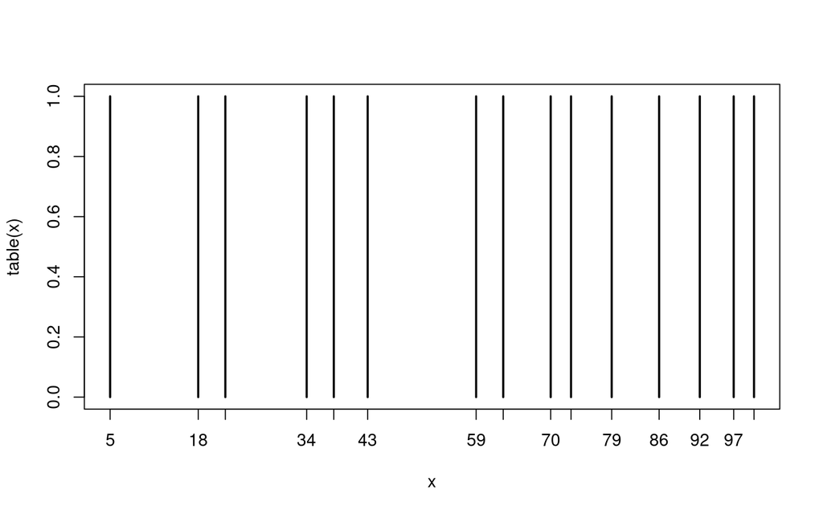

```r
plot(table(x))
```

```r
flores.elegidas.10.sin = sample(1:150, 10, FALSE)
(muestra.iris.10.sin = iris[flores.elegidas.10.sin,])
```

```
##     Sepal.Length Sepal.Width Petal.Length Petal.Width    Species
## 114          5.7         2.5          5.0         2.0  virginica
## 144          6.8         3.2          5.9         2.3  virginica
## 79           6.0         2.9          4.5         1.5 versicolor
## 113          6.8         3.0          5.5         2.1  virginica
## 88           6.3         2.3          4.4         1.3 versicolor
## 17           5.4         3.9          1.3         0.4     setosa
## 101          6.3         3.3          6.0         2.5  virginica
## 67           5.6         3.0          4.5         1.5 versicolor
## 130          7.2         3.0          5.8         1.6  virginica
## 145          6.7         3.3          5.7         2.5  virginica
```

## Muestreo sistemático

Suponiendo que los individuos de una población están dados de forma ordenada, se escoge el primer individuo de la población al azar, y luego se escogen los demás con intervalos constantes.

obtener una muestra sistemática de tamaño 10 del dataset `iris`

```r
(primera.flor = sample(1:150, 1))
```

```
## [1] 104
```

```r
(incremento = floor(150/10))
```

```
## [1] 15
```

```r
flores.elegidas.10.sis =
  seq(from=primera.flor, by=incremento, length.out=10)
flores.elegidas.10.sis = flores.elegidas.10.sis %% 150
(muestra.iris.10.sis = iris[flores.elegidas.10.sis,])
```

```
##     Sepal.Length Sepal.Width Petal.Length Petal.Width    Species
## 104          6.3         2.9          5.6         1.8  virginica
## 119          7.7         2.6          6.9         2.3  virginica
## 134          6.3         2.8          5.1         1.5  virginica
## 149          6.2         3.4          5.4         2.3  virginica
## 14           4.3         3.0          1.1         0.1     setosa
## 29           5.2         3.4          1.4         0.2     setosa
## 44           5.0         3.5          1.6         0.6     setosa
## 59           6.6         2.9          4.6         1.3 versicolor
## 74           6.1         2.8          4.7         1.2 versicolor
## 89           5.6         3.0          4.1         1.3 versicolor
```

## Muestreo aleatorio estratificado

Este tipo de muestreo se utiliza cuando la población está clasificada en **estratos** que son de interés para la propiedad estudiada. Se toma una muestra de cada estrato y se unen en una muestra global. A este proceso se le llama **muestreo aleatorio estratificado**.

obtener una muestra estratificada por especie de tamaño 12 del dataset `iris`

```r
fls.muestra.setosa = sample(1:50, 4, replace=TRUE)
fls.muestra.versicolor = sample(51:100, 4, replace=TRUE)
fls.muestra.virginica = sample(101:150, 4, replace=TRUE)
fls.muestra =
  c(fls.muestra.setosa, fls.muestra.versicolor, fls.muestra.virginica)
(muestra.iris.est = iris[fls.muestra,])
```

```
##     Sepal.Length Sepal.Width Petal.Length Petal.Width    Species
## 41           5.0         3.5          1.3         0.3     setosa
## 31           4.8         3.1          1.6         0.2     setosa
## 49           5.3         3.7          1.5         0.2     setosa
## 9            4.4         2.9          1.4         0.2     setosa
## 79           6.0         2.9          4.5         1.5 versicolor
## 77           6.8         2.8          4.8         1.4 versicolor
## 61           5.0         2.0          3.5         1.0 versicolor
## 99           5.1         2.5          3.0         1.1 versicolor
## 136          7.7         3.0          6.1         2.3  virginica
## 138          6.4         3.1          5.5         1.8  virginica
## 146          6.7         3.0          5.2         2.3  virginica
## 115          5.8         2.8          5.1         2.4  virginica
```

## Muestreo por conglomerados

```r
library(faraway)
head(worldcup)
```

```
##                Team   Position Time Shots Passes Tackles Saves
## Abdoun      Algeria Midfielder   16     0      6       0     0
## Abe           Japan Midfielder  351     0    101      14     0
## Abidal       France   Defender  180     0     91       6     0
## Abou Diaby   France Midfielder  270     1    111       5     0
## Aboubakar  Cameroon    Forward   46     2     16       0     0
## Abreu       Uruguay    Forward   72     0     15       0     0
##
```

```r
str(worldcup)
```

```
## 'data.frame':    595 obs. of  7 variables:
##  $ Team    : Factor w/ 32 levels "Algeria","Argentina",..: 1 16 9 9 5 32 11 11 18 20 ...
##  $ Position: Factor w/ 4 levels "Defender","Forward",..: 4 4 1 4 2 2 1 2 4 1 ...
##  $ Time    : int  16 351 180 270 46 72 138 33 21 103 ...
##  $ Shots   : int  0 0 0 1 2 0 0 0 5 0 ...
##  $ Passes  : int  6 101 91 111 16 15 51 9 22 38 ...
##  $ Tackles : int  0 14 6 5 0 0 2 0 0 1 ...
##  $ Saves   : int  0 0 0 0 0 0 0 0 0 0 ...
##
```

```r
numeros.paises.elegidos = sample(1:32, 4, replace=FALSE)
(paises.elegidos = unique(worldcup$Team)[numeros.paises.elegidos])
```

```
## [1] Greece   Denmark  Germany  Honduras
## 32 Levels: Algeria Argentina Australia Brazil Cameroon Chile ... Uruguay
##
```

```r
muestra.worldcup.con = worldcup[worldcup$Team %in% paises.elegidos,]
head(muestra.worldcup.con, 8)
```

```
##                         Team   Position Time Shots Passes Tackles Saves
## Agger                Denmark   Defender  270     2    120      10     0
## Alvarez             Honduras Midfielder  180     1     57       1     0
## Avraam Papadopoulos   Greece   Defender  270     1     70       8     0
## Badstuber            Germany   Defender  167     0     84       6     0
## Beckmann             Denmark Midfielder   28     0      8       0     0
## Bendtner             Denmark    Forward  242     4     70       0     0
## Bernardez           Honduras   Defender   90     2     34       4     0
## BoatengGe            Germany   Defender  287     1    125      10     0
##
```

```r
nrow(muestra.worldcup.con)
```

```
## [1] 76
##
```

## Muestreo polietápico

```r
worldcup.pais1 = worldcup[worldcup$Team == paises.elegidos[1],]
worldcup.pais2 = worldcup[worldcup$Team == paises.elegidos[2],]
worldcup.pais3 = worldcup[worldcup$Team == paises.elegidos[3],]
worldcup.pais4 = worldcup[worldcup$Team == paises.elegidos[4],]
jugadores.pais1 = sample(1:nrow(worldcup.pais1), 5, replace=FALSE)
jugadores.pais2 = sample(1:nrow(worldcup.pais2), 5, replace=FALSE)
jugadores.pais3 = sample(1:nrow(worldcup.pais3), 5, replace=FALSE)
jugadores.pais4 = sample(1:nrow(worldcup.pais4), 5, replace=FALSE)
muestra.worldcup.pol =
  rbind(worldcup.pais1[jugadores.pais1,],
        worldcup.pais2[jugadores.pais2,],
        worldcup.pais3[jugadores.pais3,],
        worldcup.pais4[jugadores.pais4,])
muestra.worldcup.pol
```

```
##                      Team   Position Time Shots Passes Tackles Saves
## Salpingidis        Greece    Forward  121     3     28       4     0
## Charisteas         Greece    Forward   61     0     12       2     0
## Karagounis         Greece Midfielder  180     4    105       7     0
## Spiropoulos        Greece   Defender   45     1      6       2     0
## Papastathopoulos   Greece   Defender  127     0     18      10     0
## Kahlenberg        Denmark Midfielder  159     2     59       3     0
## Eriksen           Denmark Midfielder   44     1     20       1     0
## Tomasson          Denmark    Forward  176     7     51       1     0
## Kjaer             Denmark   Defender  180     1     41       3     0
## Agger             Denmark   Defender  270     2    120      10     0
## Muller            Germany    Forward  383     7    165       9     0
## Mertesacker       Germany   Defender  540     0    282       9     0
## Lahm              Germany   Defender  540     0    360      17     0
## Klose             Germany    Forward  356    11     83       4     0
## Khedira           Germany Midfielder  517     6    279      16     0
## Nunez            Honduras Midfielder  172     4     60       1     0
## Espinoza         Honduras Midfielder  135     0     36       4     0
## Thomas           Honduras Midfielder  114     0     37       5     0
## Valladares       Honduras Goalkeeper  270     0     51       0    12
## Izaguirre        Honduras   Defender  180     0     51       8     0
##
```

```r
dim(muestra.worldcup.pol)
```

```
## [1] 20  7
##
```

## Funciones de muestreo en `python`

Cargar la libraría `reticulate` para conectar `R` con `python` indicando en donde está la versión de `python` que se va a utilizar

```r
## R
Sys.setenv(RETICULATE_PYTHON='~/anaconda3/bin/python3')
library(reticulate)
#reticulate::py_config()
# https://stackoverflow.com/questions/50145643/unable-to-change-python-path-in-reticulate-r
```

```python
import random
import pandas as pd
##
random.seed(2021)
##
worldcup_py = r.worldcup
worldcup_py.head()
##
##                 Team    Position  Time  Shots  Passes  Tackles  Saves
## Abdoun       Algeria  Midfielder    16      0       6        0      0
## Abe            Japan  Midfielder   351      0     101       14      0
## Abidal        France    Defender   180      0      91        6      0
## Abou Diaby    France  Midfielder   270      1     111        5      0
## Aboubakar   Cameroon     Forward    46      2      16        0      0
numeros_paises_elegidos = random.sample(range(0,32), 4) # sin reposición
paises_elegidos = worldcup_py.Team.unique()[numeros_paises_elegidos]
paises_elegidos
##
## ['Chile', 'Greece', 'Honduras', 'France']
## Categories (32, object): ['Algeria', 'Japan', 'France', 'Cameroon', ..., 'Slovakia', 'South Korea',
##                           'South Africa', 'Serbia']
worldcup_pais1 = worldcup_py[worldcup_py.Team == paises_elegidos[0]]
worldcup_pais2 = worldcup_py[worldcup_py.Team == paises_elegidos[1]]
worldcup_pais3 = worldcup_py[worldcup_py.Team == paises_elegidos[2]]
worldcup_pais4 = worldcup_py[worldcup_py.Team == paises_elegidos[3]]
##
jugadores_pais1 = random.sample(range(0,len(worldcup_pais1)),5)
jugadores_pais2 = random.sample(range(0,len(worldcup_pais2)),5)
jugadores_pais3 = random.sample(range(0,len(worldcup_pais3)),5)
jugadores_pais4 = random.sample(range(0,len(worldcup_pais4)),5)
##
muestra_worldcup_pol = pd.concat([
  worldcup_pais1.iloc[jugadores_pais1,:],
  worldcup_pais2.iloc[jugadores_pais2,:],
  worldcup_pais3.iloc[jugadores_pais3,:],
  worldcup_pais4.iloc[jugadores_pais4,:]
])
##
muestra_worldcup_pol
##                        Team    Position  Time  Shots  Passes  Tackles  Saves
## Ponce                 Chile    Defender   270      2     113        4      0
## SuazoC                Chile     Forward   135      4      39        1      0
## Carmona               Chile  Midfielder   270      1     175        9      0
## Medel                 Chile    Defender   270      1     123        7      0
## Isla                  Chile    Defender   332      1     123       10      0
## Papastathopoulos     Greece    Defender   127      0      18       10      0
## Torosidis            Greece    Defender   235      3      74        5      0
## Gekas                Greece     Forward   169      3      26        0      0
## Katsouranis          Greece  Midfielder   234      2     115        4      0
## Tziolis              Greece  Midfielder   270      2     153        8      0
## Bernardez          Honduras    Defender    90      2      34        4      0
## Espinoza           Honduras  Midfielder   135      0      36        4      0
## Mendoza            Honduras    Defender   180      0      51        3      0
## Wilson Palacios    Honduras  Midfielder   270      0      90       14      0
## Mauricio Sabillon  Honduras    Defender    90      0      38        5      0
## Ribery               France  Midfielder   270      4     104        9      0
## Anelka               France     Forward   117      7      37        1      0
## Evra                 France    Defender   180      0      92        4      0
## Valbuena             France  Midfielder    21      1      11        1      0
## Govou                France     Forward   162      1      35        4      0
```

# Estimación puntual

## Media muestral

Sea $\ X_1,\dots,X_n\$ una m.a.s. de tamaño $n$ de una v.a. $X$ de esperanza $\mu_X$ y desviación típica $\sigma_X$

La *media muestral* es:

$$\overline{X}=\frac{X_1+\cdots+X_n}{n}$$

### Proposición

En estas condiciones,

$$E(\overline{X})=\mu_X, \qquad
\sigma_{\overline{X}}=\frac{\sigma_X}{\sqrt{n}}$$

donde $\sigma_{\overline{X}}$ es el **error estándar** de $\overline{X}$.

### Ejemplo

Comprobar las propiedades mencionadas anteriormente generando 10000 muestras de tamaño 40 (con reposición) de las longitudes del pétalo (Petal.Length) del dataset `iris`.

```r
n = 40
k = 10000
valores.medios.long.petalo =
  replicate(k, mean(sample(iris$Petal.Length, n, replace=TRUE)))
valores.medios.long.petalo[1:10]
```

```
##  [1] 4.0825 3.8325 3.4100 4.0700 3.4900 3.7425 4.0250 3.8600 3.8450 3.6250
##
```

```r
mean.s = mean(valores.medios.long.petalo)
mean.p = mean(iris$Petal.Length)
sd.s = sd(valores.medios.long.petalo) # sd calcula desviación muestral
sd.p = sd(iris$Petal.Length)/sqrt(n) # sd calcula desviación muestral
df = data.frame(
  Media=c(mean.s, mean.p),
  Desv=c(sd.s, sd.p),
  row.names=c('Muestral', 'Poblacional'))
df
```

```
##                Media      Desv
## Muestral    3.756032 0.2794886
## Poblacional 3.758000 0.2791182
##
```

```r
mn = min(valores.medios.long.petalo)
mx = max(valores.medios.long.petalo)
x = seq(mn, mx, length.out=ceiling((mx-mn)/0.01))
```

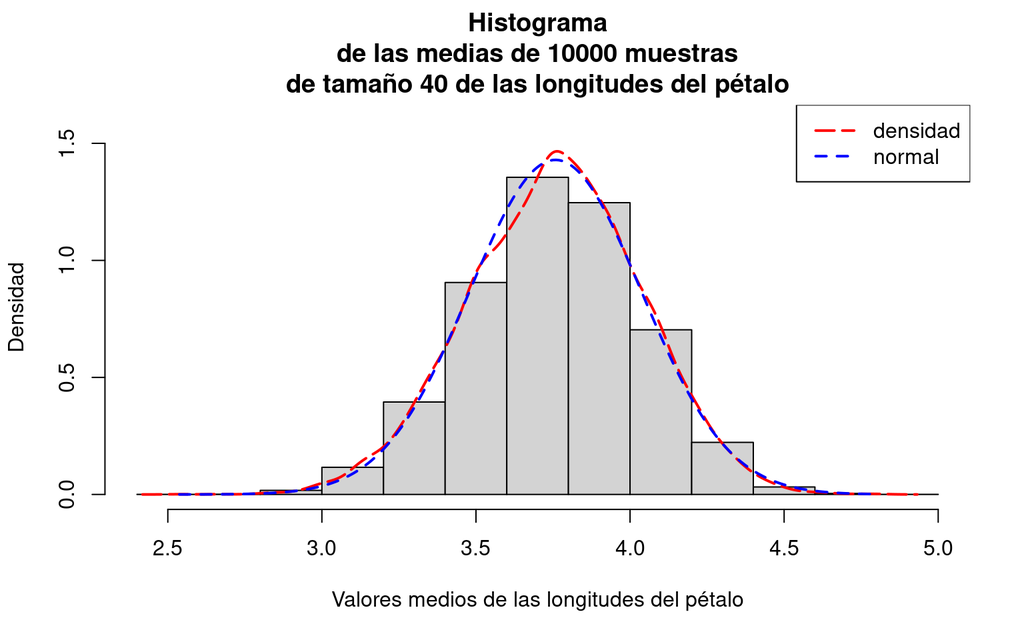

```r
v = hist(valores.medios.long.petalo, breaks=16, freq=FALSE,
  main=sprintf("Histograma\nde las medias de %d muestras\nde tamaño %d de las longitudes del pétalo", k, n),
  ylim=c(0,1.6), ylab="Densidad", xlab="Valores medios de las longitudes del pétalo")
lines(density(valores.medios.long.petalo), lwd=2, lty='longdash', col='red')
lines(x, dnorm(x, mean.p, sd.p), lwd=2, lty='dashed', col='blue')
legend("topright", legend=c("densidad", "normal"), lwd=2, col=c("red", "blue"), lty=c("longdash", "dashed"))
```

## Poblaciones normales

### Combinación lineal de distribuciones **normales**

La combinación lineal de distribuciones normales es normal. Es decir, si $\ Y_1,\dots,Y_n\$ son v.a. normales independientes, cada $\ Y_i\sim N(\mu_i,\sigma_i)$,$\$ y $\ a_1,\dots,a_n$, $\ b\in \mathbb{R}\$ entonces

$$Y=a_1Y_1+\cdots+a_nY_n+b$$

es una v.a. $\ N(\mu,\sigma)\$ donde

- $\mu=a_1\cdot\mu_1+\cdots+a_n\cdot\mu_n+b$
- $\sigma=\sqrt{a_1^2\cdot\sigma_1^2+\cdots+a_n^2\cdot\sigma_n^2}$

### Distribución de la media muestral

Si la población $X$ es normal.

Sea $\ X_1,\dots,X_n\$ una m.a.s. de una v.a. $\ X\$ de esperanza $\ \mu_X\$ y desviación típica $\ \sigma_X$.

Si $\ X\$ es $\ N(\mu_X,\sigma_X)$, $\$ entonces

$$\overline{X}\sim N\left(\mu_X,\frac{\sigma_X}{\sqrt{n}}\right)$$

y por lo tanto

$$Z=\frac{\overline{X}-\mu_X}{\frac{\sigma_X}{\sqrt{n}}}\sim N(0,1)$$

### Teorema central de límite

Sea $\ X_1,\dots,X_n\$ una m.a.s. de una v.a. $X$ **cualquiera** de esperanza $\mu_X$ y desviación típica $\sigma_X$. Cuando $n\to\infty$,

$$\overline{X}\to N\left(\mu_X,\frac{\sigma_X}{\sqrt{n}}\right)$$

y por lo tanto

$$Z=\frac{\overline{X}-\mu_X}{\frac{\sigma_X}{\sqrt{n}}}\to N(0,1)$$

(estas convergencias se refieren a las distribuciones)

### Media muestral en muestras sin reposición

Sea $\ X_1,\dots,X_n\$ una m.a. **sin reposición** de tamaño $n$ de una v.a. $X$ de esperanza $\mu_X$ y desviación típica $\sigma_X$.

Si $n$ es pequeño en relación al tamaño $N$ de la población, los teoremas enteriores funcionan (aproximadamente).

Si $n$ es grande en relación a $N$, entonces

$$E(\overline{X})=\mu_X, \qquad
\sigma_{\overline{X}}=\frac{\sigma_X}{\sqrt{n}}\cdot\sqrt{\frac{N-n}{N-1}}$$

donde $\sqrt{\frac{N-n}{N-1}}$ se llama **factor de corrección por población finita**.

El Teorema Central del Límite ya no funciona exactamente en este último caso.

## Proporción muestral

Sea $X$ una v.a. Bernoulli de parámetro $p_X$ (1 éxito, 0 fracaso). Sea $X_1,\ldots,X_n$ una m.a.s. de tamaño $n$ de $X$.

$\displaystyle S=\sum_{i=1}^{n}{X_i}$ es el número de éxitos observados donde $S\sim B(n,p)$.

La **proporción muestral** es

$$\widehat{p}_X=\frac{S}{n}$$

y es un estimador de $p_X$.

### Propiedades

- Valor esperado de la proporción muestral:

$$E(\widehat{p}_X)=p_X$$

- **Error estándar** de la proporción muestral:

$$\sigma_{\widehat{p}_X}=\sqrt{\frac{p_X(1-p_X)}{n}}$$

- Si la muestra es sin reposición y $n$ es relativamente grande con respecto a la población:

$$\sigma_{\widehat{p}_X}=\sqrt{\frac{p_X(1-p_X)}{n}}\cdot\sqrt{\frac{N-n}{N-1}}$$

- Si $n$ es grande ($n\geq30$ o $40$) y la muestra es aleatoria simple, usando el **Teorema Cental del Límite**:

$$\frac{\widehat{p}_X-p_X}{\sqrt{\frac{p_X(1-p_X)}{n}}}\approx N(0,1)$$

### Demostración

```r
flores.elegidas = sample(1:150, 60, replace=TRUE)
muestra.flores = iris[flores.elegidas,]
# Proporción de
especie = "setosa"
(freq.abs = table(muestra.flores$Species == especie))
```

```
##
## FALSE  TRUE
##    43    17
##
```

```r
prop.table(freq.abs)
```

```
##
##     FALSE      TRUE
## 0.7166667 0.2833333
##
```

```r
props.muestrales = replicate(10000,
  table(sample(iris$Species, 60, replace=TRUE)=="setosa")["TRUE"]/60)
sd(props.muestrales)
```

```
## [1] 0.06089749
```

```r
sqrt(((1/3)*(1-1/3))/(60))
```

```
## [1] 0.06085806
```

## Varianza muestral

Sea $X_1,\ldots,X_n$ una m.a.s de tamaño $n$ de una v.a. $X$ de esperanza $\mu_X$ y desviación típica $\sigma_X$.

La **varianza muestral** es

$$\widetilde{S}_{X}^{2}=\frac{\displaystyle\sum_{i=1}^{n}{\left(X_i-\overline{X}\right)^2}}{n-1}=\frac{1}{n-1}\left(\sum_{i=1}^{n}{X_i^2}-n\overline{X}^2\right)=\frac{n}{n-1}S_{X}^{2}$$

La **varianza pobracional** es

$$S_{X}^{2}=\frac{\displaystyle\sum_{i=1}^{n}{\left(X_i-\overline{X}\right)^2}}{n}=\frac{\displaystyle\sum_{i=1}^{n}{X_{i}^2}}{n}-\overline{X}^2=\frac{n-1}{n}\widetilde{S}_{X}^{2}$$

### Teorema $\ \chi_n^2$

Si la v.a. $X$ es normal, entonces $E\left(\widetilde{S}_X^2\right)=\sigma_X^2$ y la v.a.

$$\frac{(n-1)\widetilde{S}_X^2}{\sigma_X^2}\sim\chi_{n-1}^2$$

La distribución $\chi_{n}^2$, donde $n$ es un parámetro llamado **grados de libertad**, es:

$$\chi_{n}^{2}=Z_1^2+Z_2^2+\cdots+Z_n^2$$

donde $Z_1,Z_2,\ldots,Z_n$ con v.a. independientes $N(0,1)$.

- Su función de densidad es:

$$f_{\chi_n^2}(x)=\frac{1}{2^{n/2}\cdot\Gamma(n/2)}x^{(n/2)-1}e^{-x/2},\qquad\text{si }\ x\geq0$$

$\qquad$ donde $\Gamma(x)=\int_0^\infty t^{x-1}e^{-t}\ dt$, si $\ x>0$.

- Si $X_{\chi_n^2}$ es una v.a. con distribución $\chi_n^2$,

$$E\left(X_{\chi_n^2}\right)=n,\qquad Var\left(X_{\chi_n^2}\right)=2n$$

- $\chi_n^2$ se aproxima a una distribución normal $N\left(n,\sqrt{2n}\right)$ para $n$ grande ($n>40$ o $50$).

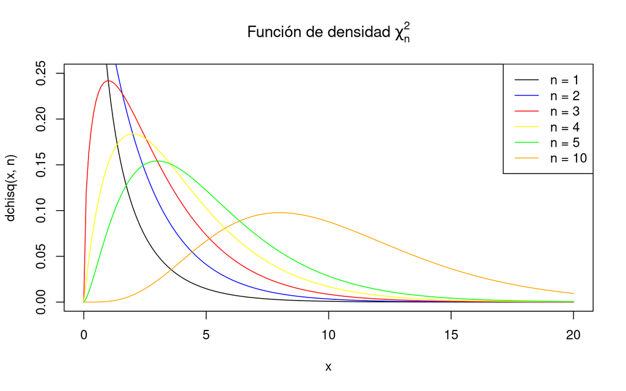

### Estimador de $N$

Si se tiene una población numerada $1,2,\dots,N$

Se toma una m.a.s. $x_1,x_2,\dots,x_n$; sea $m=\max\{x_1,x_2,\dots,x_n\}$.

El estimador no sesgado más eficiente del tamaño de la población $N$ es

$$\widehat{N}=m+\frac{m-n}{n}$$

# Intervalos de confianza

## Para $\mu$ de una población normal

### Con $\sigma$ conocida

Sea $X\sim N(\mu,\sigma)$ con $\mu$ desconocida y $\sigma$ conocida.

Tomando una m.a.s. de $X$ de tamaño $n$, con media $\overline X$.

Un intervalo de confianza del $(1-\alpha)\cdot 100\%$ para $\mu$ es

$$\left(
\overline X-z_{1-\frac{\alpha}{2}}\cdot\frac{\sigma}{\sqrt{n}},\
\overline X+z_{1-\frac{\alpha}{2}}\cdot\frac{\sigma}{\sqrt{n}}
\right)$$

donde $z_{1-\frac{\alpha}{2}}$ es el cuantil $\left(1-\frac{\alpha}{2}\right)$ de la normal estándar $Z$ (es decir, $z_{1-\frac{\alpha}{2}}=F_Z^{-1}\left(1-\frac{\alpha}{2}\right)$, o $P\left(Z\leq z_{1-\frac{\alpha}{2}}\right)=1-\frac{\alpha}{2}$).

También se puede escribir como

$$\overline X \pm z_{1-\frac{\alpha}{2}}\cdot\frac{\sigma}{\sqrt{n}}$$

Los cuantiles más usados son

| confianza $(1-\alpha)$ | Significancia $(\alpha)$ | Cuantil $\left(z_{1-\frac{\alpha}{2}}\right)$ |
| --- | --- | --- |
| 0.90 | 0.10 | 1.644854 |
| 0.95 | 0.05 | 1.959964 |
| 0.975 | 0.025 | 2.241403 |
| 0.99 | 0.01 | 2.575829 |

### Amplitud del intervalo de confianza

La amplitud $A$ del intevalo de confianza a un nivel $(1-\alpha)\cdot 100\%$ de confianza será:

$$A=
\overline{X}+z_{1-\frac{\alpha}{2}}\cdot\frac{\sigma}{\sqrt{n}}-\left(
\overline{X}-z_{1-\frac{\alpha}{2}}\cdot\frac{\sigma}{\sqrt{n}}\right)
= 2\cdot z_{1-\frac{\alpha}{2}}\cdot\frac{\sigma}{\sqrt{n}}$$

### Error máximo cometido

El error máximo, al nivel de confianza $(1-\alpha)\cdot100\%$, que se comete al estimar $\mu$ por $\overline X$ es la mitad de la amplitud,

$$z_{1-\frac{\alpha}{2}}\cdot\frac{\sigma}{\sqrt{n}}$$

### con $\sigma$ desconocida

$$\frac{\overline X-\mu}{\widetilde{S}_X/\sqrt{n}}$$

y se distribuye como una $t$ de Student con $n-1$ grados de libertad.

Sea $X\sim N(\mu,\sigma)$. Sea $X_1,X_2,\dots,X_n$ una m.a.s. de $X$, con media $\overline X$ y desviación típica muestral $\widetilde S_X$

En estas condiciones, la v.a. $t=\frac{\overline X-\mu}{\widetilde S_X/\sqrt{n}}$, sigue una distribución $t$ de Student con $n-1$ grados de libertad, $t_{n-1}$.

#### Propiedades de $t$

- $E(t_\nu)=0\$ si $\ \nu>1$
- $Var(t_\nu)=\frac{\nu}{\nu-2}\$ si $\ \nu>2$
- Su fucnión de densidad es simétrica respecto de $E(t_\nu)=0$ (como la de una $N(0,1)$):

$$P(t_\nu\leq-x)=
P(t_\nu\geq x)=
1-P(t_\nu\leq-x)$$

- Si $\nu$ es grande, su distribución es aproximadamente la de $N(0,1)$ (pero con más varianza: un poco más aplastada)

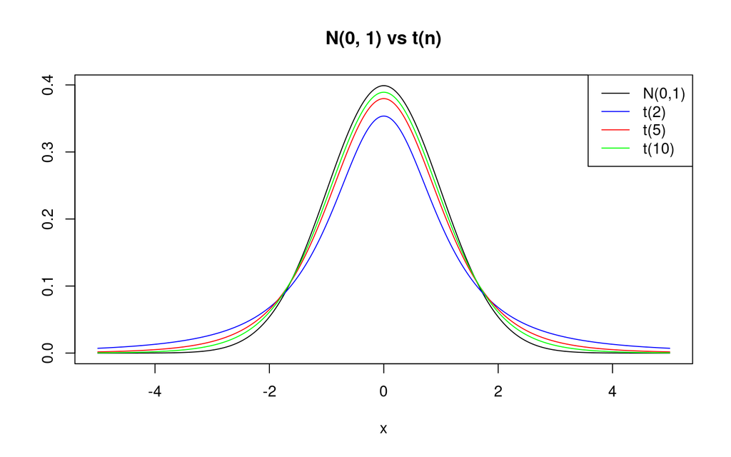

Se indica con $t_{\nu,q}$ el $q$-cuantil de una v.a. $X\sim t$:

$$P(X\leq t_{\nu,q})=q$$

Si $X\sim N(\mu,\sigma)$ con $\mu$ y $\sigma$ desconocidas, y $X_1,X_2,\dots,X_n$ es una m.a.s. de $X$ de tamaño $n$, con media $\overline X$ y varianza muestral $\widetilde S_X^2$.

El intervalo de confianza para $\mu$ a un nivel de confianza del $(1-\alpha)\cdot 100\%$ es

$$\left(
\overline X-t_{n-1,\ 1-\frac{\alpha}{2}}\cdot\frac{\widetilde S_X}{\sqrt{n}},\
\overline X+t_{n-1,\ 1-\frac{\alpha}{2}}\cdot\frac{\widetilde S_X}{\sqrt{n}}
\right)$$

#### Aproximación de una $t(\nu)$ a una $N(0,1)$

Si $n$ es grande ($n\geq40$), entonces $t_{n-1,\ 1-\frac{\alpha}{2}}\approx z_{1-\frac{\alpha}{2}}$ y se puede **aproximar** el intervalo de confianza anterior mediante la expresión siguiente:

$$\left(
\overline X-z_{1-\frac{\alpha}{2}}\cdot\frac{\widetilde S_X}{\sqrt{n}},\
\overline X+z_{1-\frac{\alpha}{2}}\cdot\frac{\widetilde S_X}{\sqrt{n}}
\right)$$

## Para $\mu$ de una población cualquiera

### Con $n$ grande ($n\geq40$)

Se puede tomar como intervalo de confianza del $(1-\alpha)\cdot100\%$ de confianza para el parámetro $\mu$ de una población cualquiera la siguiente expresión:

#### Con $\sigma$ conocida

$$\left(
\overline X-z_{1-\frac{\alpha}{2}}\cdot\frac{\sigma}{\sqrt{n}},\
\overline X+z_{1-\frac{\alpha}{2}}\cdot\frac{\sigma}{\sqrt{n}}
\right)$$

#### Con $\sigma$ desconocida

$$\left(
\overline X-z_{1-\frac{\alpha}{2}}\cdot\frac{\widetilde S_X}{\sqrt{n}},\
\overline X+z_{1-\frac{\alpha}{2}}\cdot\frac{\widetilde S_X}{\sqrt{n}}
\right)$$

### `t.test` en `R`

```r
muestra.iris = sample(1:150, 30, TRUE)
long.petalo.iris = iris[muestra.iris,]$Petal.Length
long.petalo.iris[1:10]
```

```
##  [1] 4.9 4.5 1.6 4.1 4.0 1.9 6.1 1.4 1.4 1.4
```

```r
t.test(long.petalo.iris, conf.level=0.95)$conf.int
```

```
## [1] 2.894798 4.238535
## attr(,"conf.level")
## [1] 0.95
```

### Cálculo en `python`

```python
import numpy as np
from scipy.stats import t
n = len(r["long.petalo.iris"])
xbarra = np.mean(r["long.petalo.iris"])
stilde = np.std(r["long.petalo.iris"], ddof=1)
t.interval(
  alpha = 0.95, # confidence level = 1 - alpha
  df = n-1, # degrees freedom = n - 1
  loc = xbarra, # mean = xbarra
  scale = stilde/np.sqrt(n) # std = stilde/sqrt(n)
)
## (2.8947979620895774, 4.238535371243756)
```

## Para $p$ de una población Bernoulli

```r
muestra.flores = iris[sample(1:150, 60, replace=TRUE),]
head(muestra.flores)
```

```
##     Sepal.Length Sepal.Width Petal.Length Petal.Width    Species
## 57           6.3         3.3          4.7         1.6 versicolor
## 94           5.0         2.3          3.3         1.0 versicolor
## 3            4.7         3.2          1.3         0.2     setosa
## 21           5.4         3.4          1.7         0.2     setosa
## 17           5.4         3.9          1.3         0.4     setosa
## 123          7.7         2.8          6.7         2.0  virginica
```

```r
n = nrow(muestra.flores)
x = sum(muestra.flores$Species == "setosa")
sprintf("n = %d, x = %d, x/n = %.2f", n, x, x/n)
```

```
## [1] "n = 60, x = 21, x/n = 0.35"
```

### Clopper-Pearson (método “exacto”)

Un intervalo de confianza $(p_0,\ p_1)$ del $(1-\alpha)\cdot100\%$ nivel de confianza para $p$ de una población $X$ de Bernoulli se obtiene encontrando el $p_0$ más grande y el $p_1$ más pequeño tales que

$$\sum_{k=x}^{n}{{n\choose{k}}\cdot{p}_0^k\cdot{(1-p_0)^{n-k}}}\leq\frac{\alpha}{2},\quad\sum_{k=0}^{x}{{n\choose{k}}\cdot{p}_1^k\cdot{(1-p_1)^{n-k}}}\leq\frac{\alpha}{2}$$

Usando la función `binom.exact` del paquete `epitools` de `R`, se puede calcular el intervalo de confianza del $(1-\alpha)\cdot100\%$ nivel de confianza de la siguiente manera

```r
library(epitools)
# x = número de éxitos (no la muestra)
# n = tamaño de la muestra
binom.exact(x, n, 0.95)
```

```
##    x  n proportion     lower    upper conf.level
## 1 21 60       0.35 0.2313264 0.484028       0.95
```

### Cuando $n$ es grande ($n\geq40$)

$$Z=\frac{\widehat p_X-p}{\sqrt{\frac{p\cdot(1-p)}{n}}}\approx N(0,1)$$

#### Método de Wilson

$$\left(\frac{\widehat{p}_{X}+\frac{z_{1-{\alpha}/{2}}^2}{2n}-z_{1-{\alpha}/{2}}\sqrt{\frac{\widehat{p}_{X}\widehat{q}_{X}}{n}+\frac{z_{1-{\alpha}/{2}}^2}{4n^2}}}{1+\frac{z_{1-{\alpha}/{2}}^2}{n}}\right., \left.\frac{\widehat{p}_{X}+\frac{z_{1-{\alpha}/{2}}^2}{2n}+z_{1-{\alpha}/{2}}\sqrt{\frac{\widehat{p}_{X}\widehat{q}_{X}}{n}+\frac{z_{1-{\alpha}/{2}}^2}{4n^2}}}{1+\frac{z_{1-{\alpha}/{2}}^2}{n}}\right)$$

Usando la función `binom.wilson` del paquete `epitools` de `R`, se puede calcular el intervalo de confianza del $(1-\alpha)\cdot100\%$ nivel de confianza de la siguiente manera

```r
library(epitools)
# x = número de éxitos (no la muestra)
# n = tamaño de la muestra
binom.wilson(x, n, 0.95)
```

```
##    x  n proportion     lower     upper conf.level
## 1 21 60       0.35 0.2416777 0.4763738       0.95
```

#### Método de Laplace

Si $\ n\geq100\$, $\ n\widehat p_X\geq10\$ y $\ n(1-\widehat p_X)\geq10\$, se puede usar esta fórmula

$$\widehat{p}_{X}\pm z_{1-\frac{\alpha}{2}}\sqrt{\frac{\widehat{p}_{X}
(1-\widehat{p}_{X})}{n}}$$

Usando la función `binom.approx` del paquete `epitools` de `R`, se puede calcular el intervalo de confianza del $(1-\alpha)\cdot100\%$ nivel de confianza de la siguiente manera

```r
library(epitools)
# x = número de éxitos (no la muestra)
# n = tamaño de la muestra, n >= 100
binom.approx(x, n, 0.95)
```

### Amplitud

La **amplitud** del intervalo de confianza usando la fórmula de Laplace es:

$$A=2\cdot z_{1-\frac{\alpha}{2}}\cdot\sqrt{\frac{\widehat p_X(1-\widehat p_X)}{n}}$$

### Tamaño de $n$ a partir de la amplitud

$$n\geq\left\lceil\left(\frac{z_{1-\frac{\alpha}{2}}}{A}\right)^2\right\rceil$$

## Para $\sigma$ de una población normal

Sea $X\sim N(0,1)$ con $\mu$ y $\sigma$ desconocidas, y sea $X_1,X_2,\dots,X_n$ una m.a.s. de $X$ y varianza muestral $\widetilde S_X^2$.

En estas condiciones, se tiene que la v.a. $\frac{(n-1)\cdot \widetilde S_X^2}{\sigma^2}\sim\chi_{n-1}^2$.

En las condiciones anteriores, un intervalo de confianza del $(1-\alpha)\cdot100\%$ de confianza para la varianza $\sigma^2$ de la población $X$ es:

$$\left(
\frac{(n-1)\cdot\widetilde S_X^2}{\chi_{n-1,\ 1-\frac{\alpha}{2}}^2},\
\frac{(n-1)\cdot\widetilde S_X^2}{\chi_{n-1,\ \frac{\alpha}{2}}^2}
\right)$$

donde $\chi_{\nu,\ q}^2$ es el $q$-cuantil de la distribución $\chi_\nu^2$.

### Cálculo con `R`

Usando la función `varTest` del paquete `EnvStats` de `R`, se puede calcular el intervalo de confianza del $(1-\alpha)\cdot100\%$ nivel de confianza para la varianza de la siguiente manera

```r
(amplitud.sepalo.muestra = muestra.flores$Sepal.Width)
```

```
##  [1] 3.3 2.3 3.2 3.4 3.9 2.8 3.6 3.2 3.1 3.0 2.9 2.8 2.7 3.0 3.2 4.0 2.5 3.5 3.2
## [20] 3.3 2.9 3.3 3.2 3.0 2.6 3.4 3.8 2.8 2.9 3.6 3.0 3.2 3.2 2.8 3.0 2.5 3.2 2.3
## [39] 3.3 3.7 2.8 3.1 3.0 3.9 3.3 2.2 3.4 4.1 3.0 2.5 2.5 3.0 3.1 3.1 4.1 4.1 3.2
## [58] 3.0 3.0 3.3
##
```

```r
n = length(amplitud.sepalo.muestra)
stilde = var(amplitud.sepalo.muestra)
alpha = 0.05
c(
  ((n-1)*stilde)/qchisq(1-alpha/2,n-1),
  ((n-1)*stilde)/qchisq(alpha/2,n-1)
)
```

```
## [1] 0.1427448 0.2955442
##
```

```r
library(EnvStats)
varTest(amplitud.sepalo.muestra, conf.level=1-alpha)$conf.int
```

```
##       LCL       UCL
## 0.1427448 0.2955442
## attr(,"conf.level")
## [1] 0.95
```

# Contrastes de hipótesis

- $H_0$: Hipótesis nula (se rechaza si se obtiene evidencia de $H_1$), y se define con $=$, $\leq$, o $\geq$.
- $H_1$: Hipótesis alternativa (de la que se busca evidencia), se define con $>$, $<$, o $\neq$.

## Tipos de errores

| Decisión \ Realidad | $H_0$ cierta | $H_0$ falsa |
| --- | --- | --- |
| No rechazar $H_0$ | Decisión correcta (probabilidad = $1-\alpha$) | Error tipo II (probabilidad = $\beta$) |
| Rechazar $H_0$ | Error tipo I (probabilidad = $\alpha$) | Decisión correcta (probabilidad = $1-\beta$) |

- $P(\text{Error tipo I})=P(\text{Rechazar } H_0\ |\ H_0 \text{ cierta})=\alpha$
- $P(\text{Error tipo II})=P(\text{No rechazar } H_0\ |\ H_0 \text{ falsa})=\beta$

Donde $\ \alpha\$ es el **nivel de significancia del contraste** y $\ 1-\beta\$ es la **potencia del contraste**.

La idea es que $\ \alpha\to0\$ y que $\ 1-\beta\to1$.

Cuando se hace disminuir $\ \alpha$, $\ \beta\$ tiende a aumentar.

Para que $\ \alpha\$ y $\ \beta\$ sean pequeños, lo que se suele hacer es:

1. Encontrar una regla de decisión para un $\ \alpha\$ máximo fijado.
2. Si es posible, controlar el tamaño $\ n\$ de la muestra para minimizar $\ \beta$.

## Para $\mu$ de una población normal con $\sigma$ conocida

Sea $\ X\sim N(\mu,\sigma)\$ con $\ \mu\$ desconocia y $\ \sigma\$ conocida, y sea $\ X_1, X_2,\dots,X_n\$ una m.a.s. de $\ X$, se plantea la siguiente hipótesis nula:

$$H_0:\mu=\mu_0$$

Si $\ H_0\$ es verdadera, entonces

$$Z=\frac{\overline X-\mu_0}{\frac{\sigma}{\sqrt{n}}}\sim N(0,1)$$

### Cola derecha

$$\left\{
\begin{array}{l}
H_0:\mu=\mu_0 \\[2pt]
H_1:\mu>\mu_0
\end{array}
\right.$$

Se rechaza $\ H_0\$ a favor de $\ H_1\$ si $\ \overline X\$ es “bastante más grande” que $\ \mu_0$.

#### Regla 1 ($z$ crítico)

La regla consiste en rechazar $H_0$ si el **estadístico de contraste** $Z$ es mayor a un cierto umbral, que se determina con $\alpha$, el **nivel de significación del contraste** o **error tipo I**.

Por lo tanto, se **rechaza** $H_0$ si $\displaystyle\frac{\overline X-\mu_0}{\frac{\sigma}{\sqrt{n}}}>z_{1-\alpha}$.

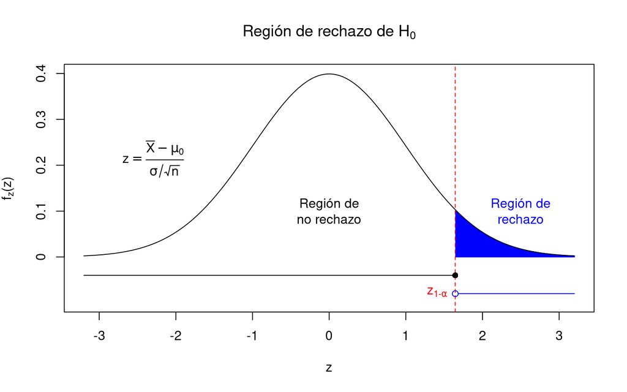

#### Regla 2 (intervalo de confianza)

No se rechaza $H_0$ si el $\mu_0$ contrastado pertenece al intervalo de confianza

$$\mu_0\in\left(\overline X-z_{1-\alpha}\cdot\frac{\sigma}{\sqrt{n}}, \ \infty\right)$$

Por lo tanto, se **rechaza** $H_0$ si $\mu_0\leq\overline X-z_{1-\alpha}\cdot\frac{\sigma}{\sqrt{n}}$

### Cola izquierda

$$\left\{
\begin{array}{l}
H_0:\mu=\mu_0 \\[2pt]
H_1:\mu<\mu_0
\end{array}
\right.$$

Se rechaza $\ H_0\$ a favor de $\ H_1\$ si $\ Z=\displaystyle\frac{\overline{X}-\mu_0}{\frac{\sigma}{\sqrt{n}}}\$ es inferior a cierto umbral que se determina con $\ \alpha$.

#### Regla 1 ($z$ crítico)

La regla consiste en rechazar $H_0$ si el **estadístico de contraste** $Z$ es menor a un cierto umbral, que se determina con $\alpha$, el **nivel de significación del contraste** o **error tipo I**.

Por lo tanto, se **rechaza** $H_0$ si $\displaystyle\frac{\overline X-\mu_0}{\frac{\sigma}{\sqrt{n}}}<z_{\alpha}$.

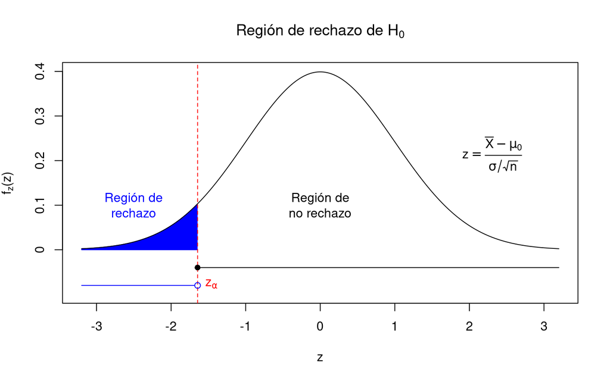

#### Regla 2 (intervalo de confianza)

No se rechaza $H_0$ si el $\mu_0$ contrastado pertenece al intervalo de confianza

$$\mu_0\in\left(-\infty,\ \overline X+z_{1-\alpha}\cdot\frac{\sigma}{\sqrt{n}}\right)$$

Por lo tanto, se **rechaza** $H_0$ si $\mu_0\geq\overline X+z_{1-\alpha}\cdot\frac{\sigma}{\sqrt{n}}$

### Dos colas

$$\left\{
\begin{array}{l}
H_0:\mu=\mu_0 \\[2pt]
H_1:\mu\neq\mu_0
\end{array}
\right.$$

Se rechaza $\ H_0\$ a favor de $\ H_1\$ si $\ Z=\displaystyle\frac{\overline{X}-\mu_0}{\frac{\sigma}{\sqrt{n}}}\$ está bastante lejos de $0$, y se determina con el valor de $\ \alpha$.

#### Regla 1 ($z$ crítico)

La regla consiste en rechazar $H_0$ si el **estadístico de contraste** $Z$ es menor a un cierto umbral o es mayor a un cierto umbral, que se determina con $\alpha$, el **nivel de significación del contraste** o **error tipo I**.

Por lo tanto, se **rechaza** $H_0$ si $\ \displaystyle\frac{\overline X-\mu_0}{\frac{\sigma}{\sqrt{n}}}<z_{\frac{\alpha}{2}}\$ o $\ \displaystyle\frac{\overline X-\mu_0}{\frac{\sigma}{\sqrt{n}}}>z_{1-\frac{\alpha}{2}}$.

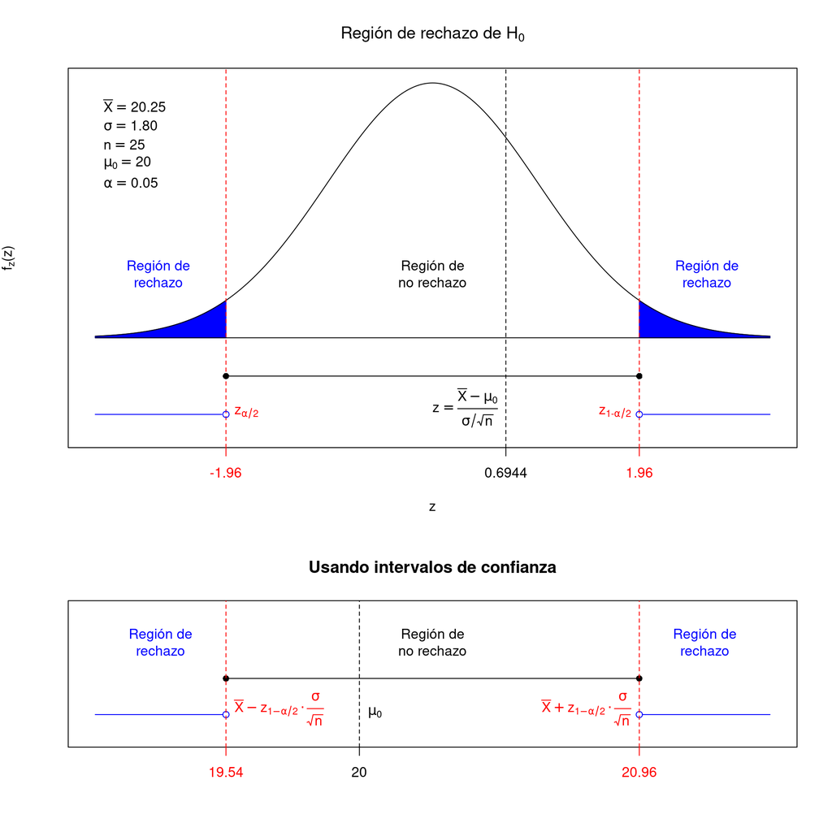

#### Regla 2 (intervalo de confianza)

No se rechaza $H_0$ si el $\mu_0$ contrastado pertenece al intervalo de confianza

Por lo tanto, se **rechaza** $H_0$ si $\mu_0\geq\overline X+z_{1-\frac{\alpha}{2}}\cdot\frac{\sigma}{\sqrt{n}}$ o si $\mu_0\leq\overline X-z_{1-\frac{\alpha}{2}}\cdot\frac{\sigma}{\sqrt{n}}$

Si $\sigma$ es desconocida, cuando $n$ es grande ($n\geq40$), entonces $Z=\displaystyle\frac{\overline{X}-\mu_0}{\frac{\widetilde{S}_X}{\sqrt{n}}}$

Faltan apuntes de p-value

Contraste para $\mu$ de normal con $\sigma$ desconocida

Con un $n$ pequeño ($n<40$)

$$T=\frac{\overline{X}-\mu_0}{\frac{\widetilde{S}_X}{\sqrt{n}}}\sim t_{n-1}$$

Con la función `t.test(x=valores.muestra, mu=mu0)` de `R` se puede hacer una prueba de hiótesis para la media $\mu$ de una población normal con $\sigma$ desconocida.

```r
t.test(
  x, # es el vector de datos que forma la muestra que analizamos
  mu, # es el valor mu0 de la hipótesis nula H_0 : mu = mu0
  alternative = "two.sided", # H_1 : "two.sided" !=, "less" < y "greater" >
  conf.level = 0.95, # 1 - alpha
  na.action = na.omit # na.omit, na.fail, na.pass
)
```

Con la función `stats.ztest()` del paquete `statsmodels.api` de `python` se puede hacer una prueba de hiótesis para la media $\mu$ de una población normal con $\sigma$ conocida.

```python
import statsmodels as sm
sm.stats.ztest(
  x1, # es el arreglo de datos que forma la muestra que analizamos
  value, # es el valor mu0 de la hipótesis nula H_0 : mu = mu0
  alternative = 'two-sided' # H_1 : "two-sided" !=, "smaller" < y "larger" >
)
```

También está la función `ttest_1samp()` del paquete `scipy.stats` en `python`, y la función `ztest()` del paquete `from statsmodels.stats import weightstats as stests` en `python`.

### Pruebas de hipótesis para $\mu$

| Población | $\sigma$ | $n$ | Estadístico | `R` | `python` |
| --- | --- | --- | --- | --- | --- |
| Normal | Conocido |  | $z=\frac{\overline{X}-\mu_0}{\sigma/\sqrt{n}}$ |  | `sm.stats.ztest()` |
| Normal | Desconocido | $n<40$ | $t=\frac{\overline{X}-\mu_0}{\widetilde{S}_X/\sqrt{n}}$ | `t.test()` |  |
| Normal | Desconocido | $n\geq40$ | $t=\frac{\overline{X}-\mu_0}{\widetilde{S}_X/\sqrt{n}}$ | `t.test()` |  |
| Cualquiera | Desconocido | $n\geq40$ | $z=\frac{\overline{X}-\mu_0}{\widetilde{S}_X/\sqrt{n}}$ |  | `sm.stats.ztest()` |

## Para $p$ de una población Bernoulli

Suponiendo que se tiene una m.a.s. de tamaño $n$ de una población Bernoulli de parámetro $p$.

Se obtienen $x_0$ éxitos, de forma que la proporción muestral de éxitos será $\widehat{p}_X=x_0/n$.

Considerando un contraste con hipótesis nula $H_0:p=p_0$

Si $H_0$ es verdadera, el número de éxitos sigue una distribución $B(n, p_0)$.

En `R` se puede hacer con la función `binom.test()`

```r
binom.test(
  x, # número natural que indica el número de éxitos
  n, # número natural que indica el tamaño de la muestra
  p, # es la probabilidad de éxito p0 que se quiere contrastar,
  alternative = "two.sided", # H_1 : "two.sided" !=, "less" < y "greater" >
  conf.level = 0.95, # 1 - alpha
)
```

Si $n$ es muy grande ($n\geq100$, $n\widehat{p}\geq10$ y $n(1-\widehat{p})\geq10$), se puede usar la función `prop.test()` de `R` que utiliza la aproximación de una binomial a una normal y hace el contraste de hipótesis

En `python` se puede hacer usando la función `proportions_ztest()` del paquete `statsmodels.api`

```python
import statsmodels.api as sm
sm.stats.proportions_ztest(
    count, # número natural que indica el número de éxitos
    nobs, # número natural que indica el tamaño de la muestra
    alternative='two-sided' # H_1 : 'two.sided' !=, 'smaller' < y 'larger' >
)
```

## Para $\sigma$ de una normal

Si $X_1, X_2, \dots, X_n$ es una m.a.s. de una v.a. $X\sim N(\mu, \sigma)$, entonces el **estadístico** $\chi^2_{n-1}=\frac{(n-1)\widetilde{S}^2_X}{\sigma^2}$ sigue una distribución $\chi^2$ con $n-1$ grados de libertad

Por lo tanto, si la hipótesis nula $H_0:\sigma=\sigma_0$ es verdadera, $\chi^2_{n-1}=\frac{(n-1)\widetilde{S}^2_X}{\sigma^2_0}$ tendrá una distribución $\chi^2$ con $n-1$ grados de libertad.

Se calcula su valor $\chi^2_0=\frac{(n-1)\widetilde{S}^2_X}{\sigma^2_0}$ sobre la muestra

| Contraste | Cola | p-value |
| --- | --- | --- |
| $\left\{\begin{array}{ll}H_0:&\sigma=\sigma_0 \quad(\text{o }\ \sigma\geq\sigma_0)\\[2pt]H_1:&\sigma<\sigma_0\end{array}\right.$ | Izquierda | $P\left(\chi^2_{n-1}\leq\chi^2_0\right)$ |
| $\left\{\begin{array}{ll}H_0:&\sigma=\sigma_0 \quad(\text{o }\ \sigma\leq\sigma_0)\\[2pt]H_1:&\sigma>\sigma_0\end{array}\right.$ | Derecha | $P\left(\chi^2_{n-1}\geq\chi^2_0\right)$ |
| $\left\{\begin{array}{ll}H_0:&\sigma=\sigma_0\\[2pt]H_1:&\sigma\neq\sigma_0\end{array}\right.$ | Ambas | $2\cdot\min\left\{P\left(\chi^2_{n-1}\leq\chi^2_0\right),\ P\left(\chi^2_{n-1}\geq\chi^2_0\right)\right\}$ |

### Cálculo en `R`

En `R`, este test se puede realizar usando la función `sigma.test()` del paquete `TeachingDemos`.

```r
sigma.test(
  x, # Vector con los datos de la muestra
  sigma = 1, # Desviación típica que se va a contrastar sigma0
  sigmasq = sigma^2, # Varianza que se va a contrastar sigma0^2
  alternative = "two.sided", # H_1 : "two.sided" !=, "less" < y "greater" >
  conf.level = 0.95 # 1 - alpha
)
```

## Para $\mu_1$ y $\mu_2$ independientes

Si se tienen dos v.a. $X_1$ y $X_2$, de medias $\mu_1$ y $\mu_2$

Se toma una m.a.s. de cada variable

$$\begin{array}{ll}
X_{1,\ 1},\ X_{1,\ 2},\ \dots,\ X_{1,\ n_1} & \text{de } X_1 \\[2pt]
X_{2,\ 1},\ X_{2,\ 2},\ \dots,\ X_{2,\ n_2} & \text{de } X_2
\end{array}$$

Sean $\overline{X}_1$ y $\overline{X}_2$ sus medias, respectivamente.

La hipótesis nula será del tipo:

$$H_0:\mu_1=\mu_2 \text{, o, equivalentemente, } H_0:\mu_1-\mu_2=0$$

### Cuando $\sigma_1$ y $\sigma_2$ son conocidas

Si $X_1$ y $X_2$ son normales, o $n_1$ y $n_2$ son grandes ($n_1, n_2\geq30$ o $40$)

Suponiendo además que se conocen las desviaciones típicas poblacionesles $\sigma_1$ y $\sigma_2$ de $X_1$ y $X_2$, respectivamente.

En este caso el **estadístico de contraste** es $\displaystyle Z=\frac{\overline{X}_1-\overline{X}_2}{\sqrt{\frac{\sigma_1^2}{n_1}+\frac{\sigma_2^2}{n2}}}$, que, si la hipótesis nula es cierta ($\mu_1=\mu_2$), se distribuye según una $N(0, 1)$.

| Contraste | p-value | Intervalo de confianza |
| --- | --- | --- |
| $\left\{\begin{array}{ll}H_0:&\mu_1=\mu_2\\[2pt]H_1:&\mu_1<\mu_2\end{array}\right.$ | $P(Z\leq z_0)$ | $\displaystyle\left(-\infty,\ \overline{X}_1-\overline{X}_2+z_{1-\alpha}\sqrt{\frac{\sigma^2_1}{n_1}+\frac{\sigma^2_2}{n_2}}\right)$ |
| $\left\{\begin{array}{ll}H_0:&\mu_1=\mu_2\\[2pt]H_1:&\mu_1>\mu_2\end{array}\right.$ | $P(Z\geq z_0)$ | $\displaystyle\left(\overline{X}_1-\overline{X}_2-z_{1-\alpha}\sqrt{\frac{\sigma^2_1}{n_1}+\frac{\sigma^2_2}{n_2}},\ \infty\right)$ |
| $\left\{\begin{array}{ll}H_0:&\mu_1=\mu_2\\[2pt]H_1:&\mu_1\neq\mu_2\end{array}\right.$ | $2\cdot P(Z\geq\|z_0\|)$ | $\displaystyle\left(\overline{X}_1-\overline{X}_2\pm z_{1-\alpha/2}\sqrt{\frac{\sigma^2_1}{n_1}+\frac{\sigma^2_2}{n_2}}\right)$ |

### Cuando $\sigma_1$ o $\sigma_2$ son desconocidas

Si $X_1$ y $X_2$ son normales, o $n_1$ y $n_2$ son grandes ($n_1, n_2\geq40$)

#### Si $\sigma_1=\sigma_2$

El estadístico de contraste es

$$T=\frac{\overline{X}_1-\overline{X}_2}{\sqrt{\left(\frac{1}{n_1}+\frac{1}{n_2}\right)\cdot\frac{(n_1-1)\widetilde{S}^2_1\ +\ (n_2-1)\widetilde{S}^2_2}{n_1+n_2-2}}}\sim t_{n_1+n_2-2}$$

que, cuando $\mu_1=\mu_2$, tiene distribución (aproximadamente, en caso de muestras grandes) $t_{n_1+n_2-2}$.

[output not shown]

#### Si $\sigma_1\neq\sigma_2$

El estadístico de contraste es

$$T=\frac{\overline{X}_1-\overline{X}_2}{\sqrt{\frac{\widetilde{S}^2_1}{n_1}+\frac{\widetilde{S}^2_2}{n_2}}}\sim t_f$$

que, cuando $\mu_1=\mu_2$, tiene distribución (aproximadamente, en caso de muestras grandes) $t_f$ con

$$f=\left\lfloor\frac{\left(\frac{\widetilde{S}^2_1}{n_1}+\frac{\widetilde{S}^2_2}{n_2}\right)^2}{\frac{1}{n_1-1}\left(\frac{\widetilde{S}^2_1}{n_1}\right)^2+\frac{1}{n_2-1}\left(\frac{\widetilde{S}^2_2}{n_2}\right)^2}\right\rfloor-2$$

#### Cálculo con `R`

Con la función `t.test()` del paquete `stats`, se puede hacer esta prueba

```r
t.test(
  x, # vector de datos 1
  y, # vector de datos 2
  alternative = "two.sided", # H_1 : "two.sided" !=, "less" < y "greater" >
  mu = 0, # mu0 donde mu1 - mu2 = mu0
  var.equal = FALSE, # booleano que indica si las varianzas son iguales o no
  conf.level = 0.95 # 1 - alpha
)
```

### Cálculo con `python`

Con la función `stats.ttest_ind()` del paquete `statsmodels.api`, se puede hacer esta prueba. (También existe en ese paquete el `stats.ztest()`).

```python
import statsmodels.api as sm
sm.stats.ttest_ind(
  x1, # vector de datos 1
  x2, # vector de datos 2
  alternative = 'two-sided', # H_1 : 'two-sided' !=, 'smaller' < y 'larger' >
  value = 0 # mu0 donde mu1 - mu2 = mu0
)
```

También está la función `ttest_ind()` del paquete `scipy.stats` en `python` y la función `ztest()` del paquete `from statsmodels.stats import weightstats as stests` en `python`

## Para $p_1$ y $p_2$

### Test de Fisher

Si se tienes dos variables $X_1$ y $X_2$ Bernoulli de proporciones $p_1$ y $p_2$, y se toma una m.a.s. de cada una, se obtiene la siguiente tabla:

|  | **$X_1$** | **$X_2$** | **Total** |
| --- | --- | --- | --- |
| **Éxitos** | $n_{11}$ | $n_{12}$ | $n_{1\bullet}$ |
| **Fracasos** | $n_{21}$ | $n_{22}$ | $n_{2\bullet}$ |
| **Total** | $n_{\bullet1}$ | $n_{\bullet2}$ | $n_{\bullet\bullet}$ |

Sea $X\sim H(n_{1\bullet},n_{2\bullet},n_{\bullet1})$, entonces

| Contraste | p-value |
| --- | --- |
| $\left\{\begin{array}{ll}H_0:&p_1=p_2\\[2pt]H_1:&p_1<p_2\end{array}\right.$ | $P(X\leq{n}_{11})$ |
| $\left\{\begin{array}{ll}H_0:&p_1=p_2\\[2pt]H_1:&p_1>p_2\end{array}\right.$ | $P(X\geq{n}_{11})$ |
| $\left\{\begin{array}{ll}H_0:&p_1=p_2\\[2pt]H_1:&p_1\neq{p_2}\end{array}\right.$ | $2\cdot\min\{P(X\leq{n}_{11}),P(X\geq{n}_{11})\}$ |

#### Odds

El **odds** de un suceso $A$ es el cociente

$$\text{Odds}(A)=\frac{P(A)}{1-P(A)}$$

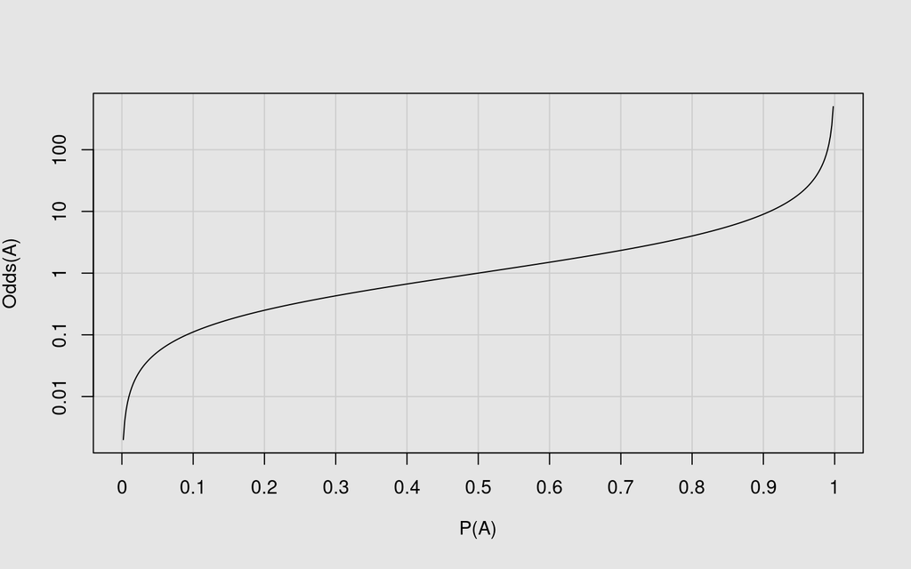

#### Odds ratio

$$\frac{\text{Odds}(A)}{\text{Odds}(B)}=\frac{p_A}{1-p_A}\left/\frac{p_A}{1-p_A}\right.$$

| Si el I.C. | Entonces |
| --- | --- |
| Contiene el $1$ | $p_1=p_2$ |
| Es menor que $1$ | $p_1<p_2$ |
| Es mayor que $1$ | $p_1>p_2$ |

Si el intervalo de confianza para **odds ratio** no contiene el valor 1, se rechaza $H_0:p_1=p_2$,

#### Cálculo en `R`

En `R`, usando la función `fisher.test` del paquete `stats`, se puede realizar este contraste de hipótesis

```r
fisher.test(
  x, # Matriz de datos, matrix(c(n11,n21,n12,n22), ncol=2)
  alternative = "two.sided", # H_1 : "two.sided" !=, "less" < y "greater" >
  conf.level = 0.95 # 1 - alpha
)
```

### Para muestras grandes

Si se tienen dos v.a. $X_1$ y $X_2$ de Bernoulli de parámetros $p_1$ y $p_2$, y se tiene una m.a.s. de cada v.a. de tamaños $n_1$ y $n_2$, respectivamente, grandes ($n_1,n_2\geq50$ o $100$):

$$\begin{array}{ll}
X_{1,1},\ X_{1,2},\ \dots,\ X_{1,n_1}&\text{de }X_1\\[2pt]
X_{2,1},\ X_{2,2},\ \dots,\ X_{2,n_2}&\text{de }X_2
\end{array}$$

Sean $\widehat{p}_1$ y $\widehat{p}_2$ sus proporciones muestrales, y suponiendo que los números de éxitos y de fracasos en cada muestra son $\geq5$ o $10$.

El **estadístico de contraste** $Z$ es:

$$Z=\frac{\widehat{p}_1-\widehat{p}_2}{\displaystyle\sqrt{\left(\frac{n_1\widehat{p}_1+n_2\widehat{p}_2}{n_1+n_2}\right)\cdot\left(1-\frac{n_1\widehat{p}_1+n_2\widehat{p}_2}{n_1+n_2}\right)\cdot\left(\frac{1}{n_1}+\frac{1}{n_2}\right)}}$$

que usando el *Teorema Central de Límite* y suponiendo cierta la hipótesis nula $H_0:p_1=p_2$, tiene aproximadamente una distribución $N(0,1)$.

Sea $z_0$ el valor del **estadístico de contraste** usando las proporciones muestrales $\widehat{p}_1$ y $\widehat{p}_2$.

| Contraste | p-value |
| --- | --- |
| $\left\{\begin{array}{ll}H_0:&p_1=p_2\\[2pt]H_1:&p_1<p_2\end{array}\right.$ | $P(Z\leq{z_0})$ |
| $\left\{\begin{array}{ll}H_0:&p_1=p_2\\[2pt]H_1:&p_1>p_2\end{array}\right.$ | $P(X\geq{z_0})$ |
| $\left\{\begin{array}{ll}H_0:&p_1=p_2\\[2pt]H_1:&p_1\neq{p_2}\end{array}\right.$ | $2\cdot P(Z\geq{\|z_0\|})$ |

#### Cálculo en `R`

En `R`, usando la función `prop.test` del paquete `stats`, se puede realizar este contraste de hipótesis

```r
prop.test(
  x, # vector con el número de éxitos de las dos muestras c(x1,x2)
  n, # vector con el tamaño de las dos muestras c(n1,n2)
  alternative = "two.sided", # H_1 : "two.sided" !=, "less" < y "greater" >
  conf.level = 0.95 # 1 - alpha
)
```

## Para $\sigma_1^2$ y $\sigma_2^2$ de normales

El estadístico de contraste es el siguiente

$$F=\frac{\widetilde{S}^2_1}{\widetilde{S}^2_2}$$
que, si las dos poblaciones son normales y la hipótesis nula $H_0:\sigma_1=\sigma_2$ es cierta, tiene una distribución $F$ de Fisher con grados de libertad $n_1-1$ y $n_2-1$.

Sea $f_0$ el valor que toma usando las desviaciones típicas muestrales.

| Contraste | p-value |
| --- | --- |
| $\left\{\begin{array}{ll}H_0:&\sigma_1=\sigma_2 \quad\left(\text{o }\ \frac{\sigma_1^2}{\sigma_2^2}=1\right)\\[2pt]H_1:&\sigma_1<\sigma_2\end{array}\right.$ | $P\left(F_{n_1-1,\ n_2-1}\leq{f_0}\right)$ |
| $\left\{\begin{array}{ll}H_0:&\sigma_1=\sigma_2 \quad\left(\text{o }\ \frac{\sigma_1^2}{\sigma_2^2}=1\right)\\[2pt]H_1:&\sigma_1>\sigma_2\end{array}\right.$ | $P\left(F_{n_1-1,\ n_2-1}\geq{f_0}\right)$ |
| $\left\{\begin{array}{ll}H_0:&\sigma_1=\sigma_2 \quad\left(\text{o }\ \frac{\sigma_1^2}{\sigma_2^2}=1\right)\\[2pt]H_1:&\sigma_1\neq\sigma_2\end{array}\right.$ | $2\cdot\min\left\{P\left(F_{n_1-1,\ n_2-1}\leq{f_0}\right),\ P\left(F_{n_1-1,\ n_2-1}\geq{f_0}\right)\right\}$ |

Intervalo de confianza

$$\left(\frac{\widetilde{S}^2_1}{\widetilde{S}^2_2}\cdot{F}_{n_1-1,\ n2-1,\ \frac{\alpha}{2}},\ \frac{\widetilde{S}^2_1}{\widetilde{S}^2_2}\cdot{F}_{n_1-1,\ n2-1,\ 1-\frac{\alpha}{2}}\right)$$

#### Cálculo en `R`

En `R`, usando la función `var.test` del paquete `stats`, se puede realizar este contraste de hipótesis

```r
var.test(
  x, # vector de datos de la muestra de la v.a. X1
  y, # vector de datos de la muestra de la v.a. X2
  alternative = "two.sided", # H_1 : "two.sided" !=, "less" < y "greater" >
  conf.level = 0.95 # 1 - alpha
)
```

Cuando se duda de la normalidad de las poblaciones, se puede usar el **test de Fligner-Killeen**, que es un test no paramétrico y está implementado en la función `fligner.test()` del paquete `stats`

```r
##
## H_0 : sigma1 = sigma2
## H_1 : sigma1 ≠ sigma2
##
fligner.test(
  x # lista con los vectores de datos de la muestra list(x1, x2)
)
```

La ventaja de este test es que no se necesita la normalidad de las poblaciones, aunque su potencia es inferior al test de **Fisher**.

## Para $p$ emparejadas

Suponiendo que se evalúan dos características dicotómicas sobre una misma muestras de $n$ sujetos. Se resumen los resultados en la siguiente tabla

| **Característica 2** | **Característica 1** **Sí** | **Característica 1** **No** |
| --- | --- | --- |
| **Sí** | $a$ | $b$ |
| **No** | $c$ | $d$ |

Se cumple que $a+b+c+d=n$. Llamando $p_1$ a la proporción poblacional de individuos con la característica 1 ($(a+c)/n$), y $p_2$ a la proporción poblacional de individuos con la característica 2 ($(a+b)/2$).

$$\left\{\begin{array}{l}H_0:p_1=p_2\\[2pt]H_1:p_1\neq{p}_2\end{array}\right.$$

$$Z=\frac{\frac{b}{n}-\frac{c}{n}}{\sqrt{\frac{b+c}{n^2}}}=\frac{b-c}{\sqrt{b+c}}\sim{N}(0,1)$$

Sea $z_0$ el valor que toma sobre los valores muestrales. Por lo tanto, el p-value será: $p=2\cdot{P}(Z\geq|z_0|)$.

### Cálculo en `R`

En `R`, usando la función `mcnemar.test` del paquete `stats`, se puede realizar este contraste de hipótesis

```r
mcnemar.test(
  x, # matriz de datos de la muestra matrix(c(a,b,c,d),byrow=T,nrow=2)
)
```

### Otra forma de hacer el test

Otra posibilidad para realizar un contraste de dos proporciones usando muestras emparejadas, que no requiere ninguna hipótesis sobre los tamaños de las muestras, es usar de manera adecuada la función `binom.test()`.

Considerando la siguiente tabla, donde ahora se dan las probabilidades poblacionales de las cuatro combinaciones de resultados

```r
##                   Característica 1
## Característica 2  Sí   No
##               Sí  p11  p01
##               No  p10  p00
```

La gracia ahora está en que si $H_0:p_{10}=p_{01}$ es cierta, entonces, el total de casos discordantes, el número de sujetos en los que la característica 1 da Sí y la característica 2 da No sigue una ley binomial con $p=0.5$. Por lo tanto, se puede realizar este contraste realizando un test binomial exacto tomando como muestra los casos discordantes de la muestra ($b+c$), como éxitos los sujetos que han dado Sí en la característica 1 y No en la característica 2 ($c$), y con proporción a contrastar $p=0.5$.

La ventaja de este test es que su validez no requiere un tamaño de muestra específico, y su desventaja es que el intervalo de confianza será para $p_{10}/(p_{10}+p_{01})$ lo cual no es válido para el análisis que se está haciendo.